# Disproportionate exposure to urban heat island intensity in the USA

December 6, 2022

## Introduction

- Urban areas are usually warmer than the rural areas that surround them — Urban heat island
- It could occurs because cities consume huge amounts of energy in electricity and fuel, have less vegetation to provide shade and cooling, and are built of materials that absorb and store heat
- Heat exposure is associated with heat-related mortality, illness, and non-fatal health outcomes.
- Urban heat islands (UHI) might disproportionately impact vulnerable communities (e.g., lower income communities, older people, and black communities)
- Well-targeted interventions are needed to adapt and mitigate to the UHI effect

## Research questions

1. Is UHI intensity disproportionately affecting vulnerable communities? What type of communities are affected more by the UHI intensity?
2. How vegetation index and digital elevation model affect UHI intensity?

## Data description

- **Urban Heat Island data**
  - UHI = urban heat island (55,871 obs.)
  - also use NDVI (vegetation index), LST (land surface temperature); DEM (digital elevation model)
  - source: [Chakraborty, 2020](https://data.mendeley.com/datasets/x9mv4krnm2/3) (data.mendeley.com)
- **Demographic data**
  - age, sex, race at the census tract-level demographic data (74,001 obs)
  - source: [American Community Survey, 2017](https://data.census.gov/table?q=age+&g=0100000US$1400000&y=2017&tid=ACSST5Y2017.S0101) (data.census.gov)
- **Socioeconomic data**
  - poverty rate (74,001 obs); source: [American Community Survey, 2017](https://data.census.gov/table?q=age+&g=0100000US$1400000&y=2017&tid=ACSST5Y2017.S0101) (data.census.gov)

**Representative population:**

- Unit of analysis: tracts by census id (42,183 obs.)
- Population: all tract across US observed in 2017

## Descriptive Findings

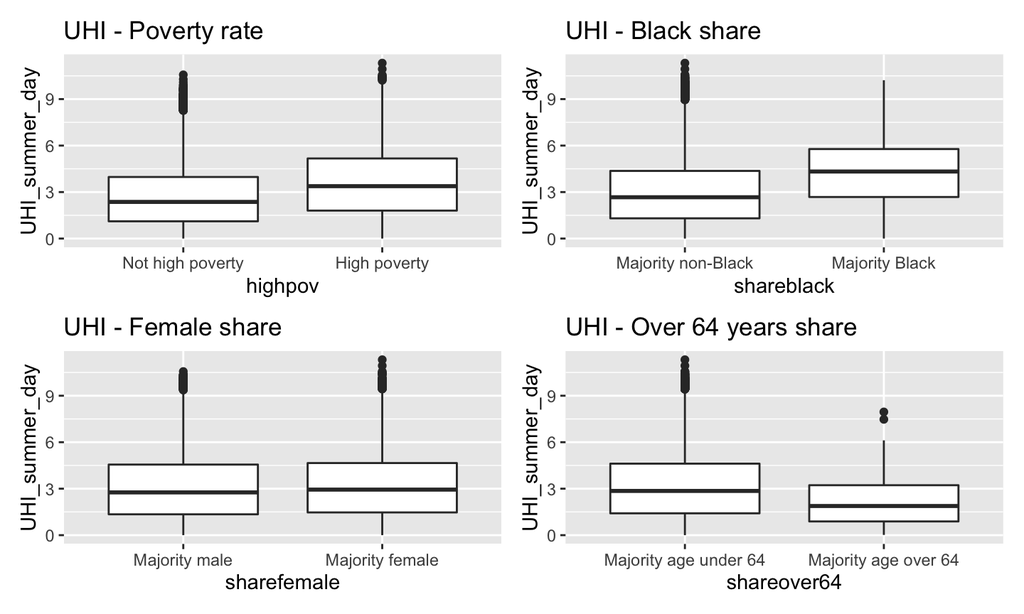

## Descriptive Findings

Some of the highest UHI intensity cities relatively have high **poverty rate** and high share of **black and female population**

20 cities with highest UHI intensity

| Urban_name | total | UHI_mean | NDVI_mean | DEM_mean | povt_rate | shareblack | sharefemale | shareover64 |
| --- | --- | --- | --- | --- | --- | --- | --- | --- |
| New Orleans, LA | 829397 | 6.25 | 0.35 | 4.91 | 22.46 | 0.43 | 0.52 | 0.14 |
| New York–Newark, NY–NJ–CT | 16523795 | 5.23 | 0.40 | 29.46 | 14.88 | 0.21 | 0.52 | 0.14 |
| Manchester, NH | 116143 | 4.98 | 0.55 | 88.61 | 15.98 | 0.05 | 0.49 | 0.14 |
| Buffalo, NY | 847328 | 4.88 | 0.52 | 193.05 | 19.51 | 0.19 | 0.52 | 0.16 |
| Providence, RI–MA | 1031247 | 4.81 | 0.54 | 38.92 | 15.58 | 0.07 | 0.51 | 0.15 |
| Antioch, CA | 235279 | 4.78 | 0.27 | 30.12 | 13.49 | 0.15 | 0.51 | 0.12 |
| Bridgeport–Stamford, CT–NY | 740795 | 4.72 | 0.62 | 37.73 | 11.04 | 0.14 | 0.52 | 0.15 |
| Boston, MA–NH–RI | 3736637 | 4.62 | 0.55 | 34.83 | 12.48 | 0.11 | 0.52 | 0.14 |
| Urban Honolulu, HI | 689569 | 4.62 | 0.35 | 64.72 | 10.62 | 0.03 | 0.49 | 0.16 |
| York, PA | 182187 | 4.50 | 0.49 | 146.10 | 18.90 | 0.14 | 0.52 | 0.15 |
| Beaumont, TX | 112711 | 4.45 | 0.45 | 14.06 | 19.52 | 0.45 | 0.51 | 0.15 |
| San Juan, PR | 1637929 | 4.43 | 0.43 | 63.59 | 40.48 | 0.12 | 0.53 | 0.19 |
| San Francisco–Oakland, CA | 2266986 | 4.37 | 0.31 | 34.50 | 11.67 | 0.10 | 0.51 | 0.14 |
| Reading, PA | 244899 | 4.32 | 0.52 | 107.20 | 21.32 | 0.08 | 0.51 | 0.14 |
| Detroit, MI | 3218926 | 4.20 | 0.50 | 203.92 | 21.17 | 0.36 | 0.52 | 0.15 |
| Hartford, CT | 718598 | 4.19 | 0.61 | 54.04 | 15.12 | 0.18 | 0.52 | 0.15 |
| Syracuse, NY | 329974 | 4.14 | 0.55 | 144.20 | 23.11 | 0.18 | 0.52 | 0.14 |
| Houston, TX | 4973841 | 4.13 | 0.39 | 27.13 | 17.57 | 0.20 | 0.50 | 0.10 |
| Scranton, PA | 298887 | 4.09 | 0.52 | 227.06 | 19.00 | 0.05 | 0.51 | 0.19 |
| Philadelphia, PA–NJ–DE–MD | 4755246 | 4.07 | 0.50 | 48.08 | 15.48 | 0.26 | 0.52 | 0.15 |

## Descriptive Findings

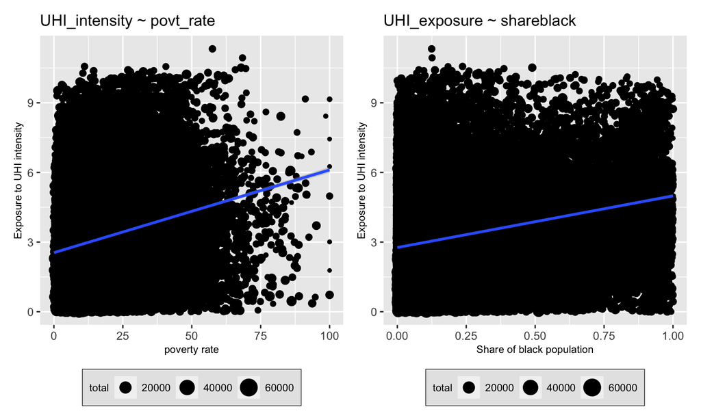

## Descriptive Findings

|  | Majority non-Black | Majority Black | diff |
| --- | --- | --- | --- |
| Not high poverty | 2.5242798 | 3.8919328 | 1.3676530 |
| high poverty | 3.2812892 | 4.1776046 | 0.8963154 |
| diff | 0.7570094 | 0.2856718 | -0.4713376 |

|  | Majority age under 64 | Majority age over 64 | diff |
| --- | --- | --- | --- |
| Majority non-Black | 2.850630 | 1.990972 | -0.8596587 |
| Majority Black | 4.126787 | 7.475126 | 3.3483391 |
| diff | 1.276157 | 5.484155 | 4.2079978 |

|  | Majority male | Majority female | diff |
| --- | --- | --- | --- |
| Majority non-Black | 2.853403 | 2.837770 | -0.0156334 |
| Majority Black | 4.097002 | 4.136468 | 0.0394658 |
| diff | 1.243599 | 1.298698 | 0.0550991 |

## Regression

\[ \begin{multline*} uhiexp = \beta_{0} + \beta_{1}highpov + \beta_{2}shareblack + \beta_{3}sharefemale \\ + \beta_{4}shareover64 + \beta_{5}highpov*shareblack + \beta_{6}highpov*sharefemale \\ + \beta_{7}highpov*shareover64 + \beta_{8}shareblack*sharefemale \\ + \beta_{9}shareblack*shareover64 + \beta_{10}sharefemale*shareover64 \\ + \beta_{11}highpov*shareblack*sharefemale + \beta_{12}highpov*shareblack*shareover64 \\ + \beta_{13}shareblack*sharefemale*shareover64 \\ + \beta_{14}highpov*shareblack*sharefemale*shareover64 +\varepsilon \end{multline*} \]

## Regression Result

[output not shown]

## Regression 2

\[ UHII = \beta_{0} + \beta_{1}NDVI + \beta_{2}DEM + \varepsilon \]

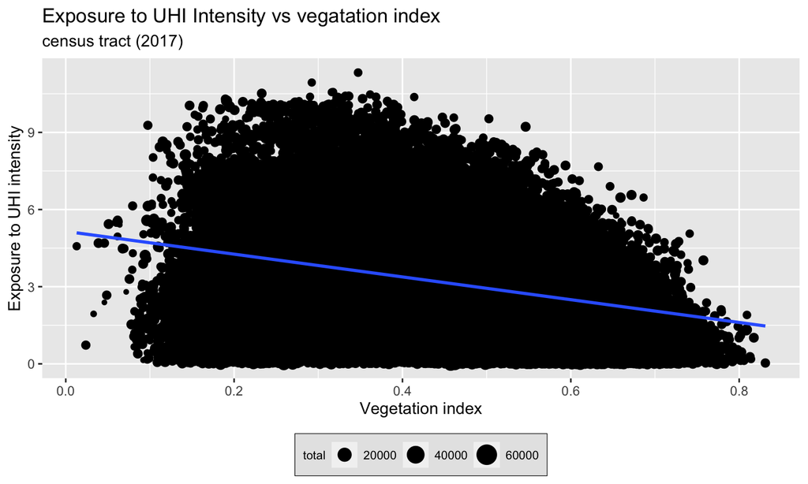

## Regression of UHI ~ NDVI + DEM

**Results**

|  | *Dependent variable:* |  |
| --- | --- | --- |
|  | UHI_summer_day |  |
|  | (1) | (2) |
| NDVI_urb_summer | -4.224*** | -4.687 |
| DEM_urb |  | -0.002 |
| Constant | 4.874*** | 5.489*** |
|  | (0.014) | (0.014) |
| Observations | 42,183 | 42,183 |
| Adjusted R<sup>2</sup> | 0.091 | 0.177 |
| *Note:* | p<0.1; p<0.05; p<0.01 |  |

## Findings

- There is an increase of **0.653** in a census tract with higher poverty, higher share of black population, higher female proportion, and higher older people (not statistically significant)
- There is an increase of **0.146** in a census tract with higher poverty level, higher share of black population, and higher share of female (not statistically significant)
- There is an increase by **5.084** in census tract with higher share of black and older people, and an increase by **0.415** in a census tract with higher level of female and older people (statistically significant)
- There is negative association between Urban heat island (UHI intensity) and vegetation index (NDVI)
- City in New Orleans, New York, New Jersey, and Connecticut is cities with highest urban heat island intensity

## Mapping New Orleans

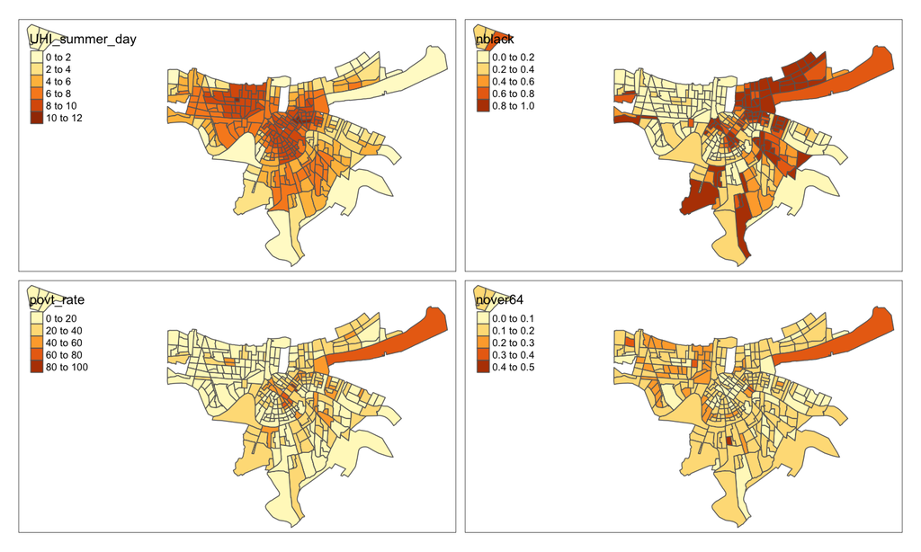

## Mapping New Hampsire

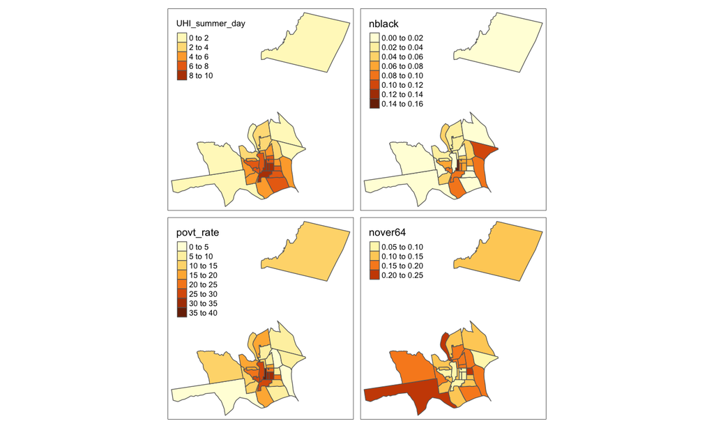

## Recommendation and limitation

- Even though we are able to generalize the effect of UHI to particular vulnerable communities, but the impact will be different in each cities, therefore, further detailed intra-city research is required.
- Our UHI ~ NDVI and DEM regression might suffer from omitted variable bias, therefore further data collection is required to understand the causality between UHI and NDVI, for example, panel data.